# Wisconsin Cancer dataset: KNN & Random Forest

Nabila Zaman

The dataset for HW5 is the same as the midterm. The four features we are interested in are radius_mean, texture_mean, smoothness_mean, compactness_mean.  
Remove 20% of your data and save it as test_set and the other 80% as training_set. a. Make sure your datasets will have the same ratio of Benign and Malignant.

```r
read.csv("data.csv", header=T, row.names=1)->cancer_data # reading the file and calling it cancer_data.
head(cancer_data)
```

```
##          diagnosis radius_mean texture_mean perimeter_mean area_mean
## 842302           M       17.99        10.38         122.80    1001.0
## 842517           M       20.57        17.77         132.90    1326.0
## 84300903         M       19.69        21.25         130.00    1203.0
## 84348301         M       11.42        20.38          77.58     386.1
## 84358402         M       20.29        14.34         135.10    1297.0
## 843786           M       12.45        15.70          82.57     477.1
##          smoothness_mean compactness_mean concavity_mean concave.points_mean
## 842302           0.11840          0.27760         0.3001             0.14710
## 842517           0.08474          0.07864         0.0869             0.07017
## 84300903         0.10960          0.15990         0.1974             0.12790
## 84348301         0.14250          0.28390         0.2414             0.10520
## 84358402         0.10030          0.13280         0.1980             0.10430
## 843786           0.12780          0.17000         0.1578             0.08089
##          symmetry_mean fractal_dimension_mean radius_se texture_se perimeter_se
```

[output cut: 41 more lines]

```r
cancer_data[c("diagnosis","radius_mean", "texture_mean", "smoothness_mean", "compactness_mean")] -> cancer_df
head(cancer_df)
```

```
##          diagnosis radius_mean texture_mean smoothness_mean compactness_mean
## 842302           M       17.99        10.38         0.11840          0.27760
## 842517           M       20.57        17.77         0.08474          0.07864
## 84300903         M       19.69        21.25         0.10960          0.15990
## 84348301         M       11.42        20.38         0.14250          0.28390
## 84358402         M       20.29        14.34         0.10030          0.13280
## 843786           M       12.45        15.70         0.12780          0.17000
```

```r
cancer_df$diagnosis = as.factor(cancer_df$diagnosis)
```

```r
table(cancer_df$diagnosis)
```

```
##
##   B   M
## 357 212
```

```r
# Balancing the dataset to make sure your test_set and training_set datasets will have the same proportion of Benign and Malignant.

Benign<-cancer_df[which(cancer_df[,"diagnosis"] == "B"),]
Malignant<-cancer_df[which(cancer_df[,"diagnosis"] == "M"),]
sample(1:nrow(Benign), nrow(Malignant))->rand.0
Benign[rand.0,]->BT
Malignant->MT
```

```r
table(BT[, "diagnosis"])
```

```
##
##   B   M
## 212   0
```

```r
table(MT[, "diagnosis"])
```

```
##
##   B   M
##   0 212
```

```r
# Splitting the data into training and test set
set.seed(900)
training.split<-rbind(BT, MT)
split<-sample(nrow(training.split), floor(nrow(training.split) * 0.8)) # Storing 80% data as training set
split.train<-training.split[split,]
split.test<-training.split[-split,]
```

```r
table(split.train[, "diagnosis"])
```

```
##
##   B   M
## 170 169
```

Part 1. KNN Use K-NN to classify the test_set based on the values from training_set. a. Try different k values. Which gives the best result? b. Calculate the AUC of the best KNN model.

NOTE:The larger the k, the more smooth the separation between them, where as the smaller the k, the tighter the boundaries making them more prone to over-fitting.

```r
library("class")

# Building a KNN model with K = 1

KNN.1 = knn(split.train[,c("radius_mean", "texture_mean", "smoothness_mean", "compactness_mean")], split.test[,c("radius_mean", "texture_mean", "smoothness_mean", "compactness_mean")],
               split.train$diagnosis, k=1)
table(KNN.1, split.test$diagnosis)
```

```
##
## KNN.1  B  M
##     B 33  4
##     M  9 39
```

```r
# Building a KNN model with K = 5

KNN.5 = knn(split.train[,c("radius_mean", "texture_mean", "smoothness_mean", "compactness_mean")], split.test[,c("radius_mean", "texture_mean", "smoothness_mean", "compactness_mean")],
               split.train$diagnosis, k=5)
table(KNN.5, split.test$diagnosis)
```

```
##
## KNN.5  B  M
##     B 35  4
##     M  7 39
```

```r
# Building a KNN model with K = 10

KNN.10 = knn(split.train[,c("radius_mean", "texture_mean", "smoothness_mean", "compactness_mean")], split.test[,c("radius_mean", "texture_mean", "smoothness_mean", "compactness_mean")],
               split.train$diagnosis, k=10)
table(KNN.10, split.test$diagnosis)
```

```
##
## KNN.10  B  M
##      B 35  5
##      M  7 38
```

```r
# Building a KNN model with K = 18

KNN.18 = knn(split.train[,c("radius_mean", "texture_mean", "smoothness_mean", "compactness_mean")], split.test[,c("radius_mean", "texture_mean", "smoothness_mean", "compactness_mean")],
               split.train$diagnosis, k=18)
table(KNN.18, split.test$diagnosis)
```

```
##
## KNN.18  B  M
##      B 35  3
##      M  7 40
```

```r
# Building a KNN model with K = 50

KNN.50 = knn(split.train[,c("radius_mean", "texture_mean", "smoothness_mean", "compactness_mean")], split.test[,c("radius_mean", "texture_mean", "smoothness_mean", "compactness_mean")],
               split.train$diagnosis, k=50)
table(KNN.50, split.test$diagnosis)
```

```
##
## KNN.50  B  M
##      B 35  1
##      M  7 42
```

```r
# Building a KNN model with K = 100

KNN.100 = knn(split.train[,c("radius_mean", "texture_mean", "smoothness_mean", "compactness_mean")], split.test[,c("radius_mean", "texture_mean", "smoothness_mean", "compactness_mean")],
               split.train$diagnosis, k=100)
table(KNN.100, split.test$diagnosis)
```

```
##
## KNN.100  B  M
##       B 35  1
##       M  7 42
```

```r
# Building a KNN model with K = 339

KNN.339 = knn(split.train[,c("radius_mean", "texture_mean", "smoothness_mean", "compactness_mean")], split.test[,c("radius_mean", "texture_mean", "smoothness_mean", "compactness_mean")],
               split.train$diagnosis, k=339)
table(KNN.339, split.test$diagnosis)
```

```
##
## KNN.339  B  M
##       B 42 43
##       M  0  0
```

```r
# Trying different k values to identify which  value gives the best result using a for loop

data_KNN<-function(n){
  out<-matrix(data=NA, nrow = 4, ncol = n)
  rownames(out)<-c("Accuracy:","Precision:","Recall","TNR:")
  for (i in 1:n){
    data_knn <-  knn(split.train[,c("radius_mean", "texture_mean", "smoothness_mean", "compactness_mean")],
                     split.test[,c("radius_mean", "texture_mean", "smoothness_mean", "compactness_mean")],
                     split.train$diagnosis, k=i)

  # calculating accuracy
  confmat <- table(data_knn, split.test$diagnosis)
  TP = confmat["B","B"]
  TN = confmat["M","M"]
  FP = confmat["M","B"]
  FN = confmat["B","M"]

  Accuracy_of_k = (TP+TN)/(TP+TN+FP+FN)

  # calculating precision
  precision_of_k = (TP)/(TP+FP)

  # calculating recall
  recall_of_k=(TP)/(TP+FN)

  # calculating TNR
  TNR_of_k=(TN)/(TN+FP)

  out[,i]=c(Accuracy_of_k,precision_of_k,recall_of_k,TNR_of_k)
  }
  return(out)
}
```

```r
data_KNN(30) # to print the first 30 k values
```

```
##                 [,1]      [,2]      [,3]      [,4]      [,5]      [,6]
## Accuracy:  0.8470588 0.8352941 0.8470588 0.8705882 0.8705882 0.8705882
## Precision: 0.7857143 0.7619048 0.7857143 0.8333333 0.8333333 0.8333333
## Recall     0.8918919 0.8888889 0.8918919 0.8974359 0.8974359 0.8974359
## TNR:       0.8125000 0.7959184 0.8125000 0.8478261 0.8478261 0.8478261
##                 [,7]      [,8]      [,9]     [,10]     [,11]     [,12]
## Accuracy:  0.8823529 0.8823529 0.8823529 0.8823529 0.8823529 0.8823529
## Precision: 0.8571429 0.8571429 0.8571429 0.8571429 0.8333333 0.8333333
## Recall     0.9000000 0.9000000 0.9000000 0.9000000 0.9210526 0.9210526
## TNR:       0.8666667 0.8666667 0.8666667 0.8666667 0.8510638 0.8510638
##                [,13]     [,14]     [,15]     [,16]     [,17]     [,18]
## Accuracy:  0.8823529 0.8823529 0.8705882 0.8823529 0.8823529 0.8941176
## Precision: 0.8333333 0.8571429 0.8333333 0.8571429 0.8333333 0.8333333
## Recall     0.9210526 0.9000000 0.8974359 0.9000000 0.9210526 0.9459459
## TNR:       0.8510638 0.8666667 0.8478261 0.8666667 0.8510638 0.8541667
##                [,19]     [,20]     [,21]     [,22]     [,23]     [,24]
## Accuracy:  0.8941176 0.8941176 0.8823529 0.8823529 0.8941176 0.8823529
## Precision: 0.8333333 0.8333333 0.8333333 0.8333333 0.8333333 0.8333333
## Recall     0.9459459 0.9459459 0.9210526 0.9210526 0.9459459 0.9210526
## TNR:       0.8541667 0.8541667 0.8510638 0.8510638 0.8541667 0.8510638
##                [,25]     [,26]     [,27]     [,28]     [,29]     [,30]
## Accuracy:  0.8705882 0.8823529 0.8705882 0.8823529 0.8823529 0.8705882
## Precision: 0.8333333 0.8333333 0.8333333 0.8333333 0.8333333 0.8333333
## Recall     0.8974359 0.9210526 0.8974359 0.9210526 0.9210526 0.8974359
## TNR:       0.8478261 0.8510638 0.8478261 0.8510638 0.8510638 0.8478261
```

# ANSWER:K = 19 gives the best performance

2. Calculate the AUC of the best KNN model.

```r
# To Calculate the AUC values of  KNN models
library(AUC)
data.knn.prob <- knn(split.train[,c("radius_mean","texture_mean","smoothness_mean","compactness_mean")],
               split.test[,c("radius_mean","texture_mean","smoothness_mean","compactness_mean")],
               split.train$diagnosis,k=19,prob=T)

diagnosis_test=which(data.knn.prob==0)
attr(data.knn.prob,"prob")[diagnosis_test]=1-attr(data.knn.prob,"prob")[diagnosis_test]
data.knn.prob_roc<-roc(attr(data.knn.prob,"prob"),split.test$diagnosis)
auc(data.knn.prob_roc)
```

```
## [1] 0.6727575
```

```r
# To Calculate the AUC values of  KNN models using a for loop
KNN_AUC<-function(n){
  out<-matrix(data=NA, nrow = 1, ncol = n)
  rownames(out)<-c("AUC")
  for (i in 1:n){
  data.knn.prob<-knn(split.train[,c("radius_mean","texture_mean","smoothness_mean","compactness_mean")],
                 split.test[,c("radius_mean","texture_mean","smoothness_mean","compactness_mean")],
                 split.train$diagnosis,k=i,prob=T)

  diagnosis_test=which(data.knn.prob==0)
  attr(data.knn.prob,"prob")[diagnosis_test]=1-attr(data.knn.prob,"prob")[diagnosis_test]
  data.knn.prob_roc<-roc(attr(data.knn.prob,"prob"),split.test$diagnosis)
  out[,i]=auc(data.knn.prob_roc)
  }
  return(out)
}
```

```r
KNN_AUC(30) # to print the AUC values of first 30 k values
```

```
##     [,1]      [,2]      [,3]      [,4]      [,5]      [,6]      [,7]      [,8]
## AUC  0.5 0.5960687 0.6326135 0.6611296 0.6578073 0.6531008 0.6334441 0.6306755
##         [,9]     [,10]     [,11]     [,12]     [,13]     [,14]     [,15]
## AUC 0.627907 0.6367663 0.6370432 0.6356589 0.6539313 0.6514396 0.6370432
##         [,16]     [,17]     [,18]     [,19]     [,20]     [,21]   [,22]
## AUC 0.6497785 0.6614064 0.6652824 0.6727575 0.6749723 0.6782946 0.68134
##         [,23]     [,24]     [,25]     [,26]     [,27]    [,28]     [,29]
## AUC 0.6727575 0.6760797 0.6705426 0.6630676 0.6575305 0.656423 0.6680509
##         [,30]
## AUC 0.6686047
```

Part 2: Use ggplot to draw a scatter plot using the two different variables radius_mean and texture_mean from test_set. Color them based on what the points were predicted to be in knn analysis above using your optimal k.

```r
library(ggplot2)
```

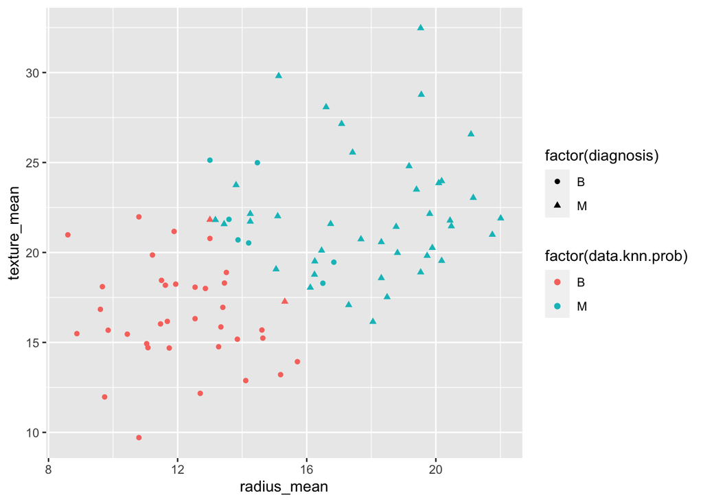

```r
#drawing a scatter plot using the two different variables radius_mean and texture_mean from test_set
ScatterPlot <- ggplot(split.test)+geom_point(mapping = aes(x=radius_mean, y=texture_mean, color=factor(data.knn.prob), shape=factor(diagnosis)))
ScatterPlot # to print the plot
```

#Part 3: Random Forest  
#Build a Random Forest model using the training_set with the four different variables listed above. #a. Try using different values for m. Which m gives the best performance?

```r
library("randomForest")
library("party")
library("AUC")
```

```r
# Building a Random Forest model using the training set
set.seed(700)
datarf = randomForest(diagnosis ~ ., data=split.train, importance=T)
datarf
```

```
##
## Call:
##  randomForest(formula = diagnosis ~ ., data = split.train, importance = T)
##                Type of random forest: classification
##                      Number of trees: 500
## No. of variables tried at each split: 2
##
##         OOB estimate of  error rate: 6.78%
## Confusion matrix:
##     B   M class.error
## B 159  11  0.06470588
## M  12 157  0.07100592
```

```r
# with mtry=1
set.seed(75)
rf1 = cforest(diagnosis ~ radius_mean + texture_mean + smoothness_mean + compactness_mean,
                       data=split.train,
                       controls=cforest_unbiased(ntree=100,mtry=1))
rf1
```

```
##
##   Random Forest using Conditional Inference Trees
##
## Number of trees:  100
##
## Response:  diagnosis
## Inputs:  radius_mean, texture_mean, smoothness_mean, compactness_mean
## Number of observations:  339
```

```r
rf1.results = predict(rf1,OOB=TRUE)

# Calculating accuracy
confmat.rf1 <- table(rf1.results, split.train$diagnosis)
TP.rf1 = confmat.rf1["B","B"]
TN.rf1 = confmat.rf1["M","M"]
FP.rf1 = confmat.rf1["M","B"]
FN.rf1 = confmat.rf1["B","M"]

Accuracy_of_rf1 = (TP.rf1+TN.rf1)/(TP.rf1+TN.rf1+FP.rf1+FN.rf1)
Accuracy_of_rf1
```

```
## [1] 0.920354
```

```r
# Calculating precision
precision_of_rf1 = (TP.rf1)/(TP.rf1+FP.rf1)
precision_of_rf1
```

```
## [1] 0.9235294
```

```r
# Calculating recall
recall_of_rf1=(TP.rf1)/(TP.rf1+FN.rf1)
recall_of_rf1
```

```
## [1] 0.9181287
```

```r
# Calculating TNR
TNR_of_rf1=(TN.rf1)/(TN.rf1+FP.rf1)
TNR_of_rf1
```

```
## [1] 0.922619
```

```r
# To find the most important Variable
varimp(rf1)
```

```
##      radius_mean     texture_mean  smoothness_mean compactness_mean
##       0.13879032       0.03120968       0.02161290       0.06975806
```

```r
# using mtry=1 building a randomForest
rf_1<-randomForest(diagnosis~.,data=split.train,importance=T,mtry=1)
rf_1
```

```
##
## Call:
##  randomForest(formula = diagnosis ~ ., data = split.train, importance = T,      mtry = 1)
##                Type of random forest: classification
##                      Number of trees: 500
## No. of variables tried at each split: 1
##
##         OOB estimate of  error rate: 6.19%
## Confusion matrix:
##     B   M class.error
## B 158  12  0.07058824
## M   9 160  0.05325444
```

```r
# with mtry=2
set.seed(70)
rf2 = cforest(diagnosis ~ radius_mean + texture_mean + smoothness_mean + compactness_mean,
                       data=split.train,
                   controls=cforest_unbiased(ntree=100,mtry=2))
rf2
```

```
##
##   Random Forest using Conditional Inference Trees
##
## Number of trees:  100
##
## Response:  diagnosis
## Inputs:  radius_mean, texture_mean, smoothness_mean, compactness_mean
## Number of observations:  339
```

```r
rf2.results = predict(rf2,OOB=TRUE)

# Calculating accuracy
confmat.rf2 <- table(rf2.results, split.train$diagnosis)
TP.rf2 = confmat.rf2["B","B"]
TN.rf2 = confmat.rf2["M","M"]
FP.rf2 = confmat.rf2["M","B"]
FN.rf2 = confmat.rf2["B","M"]

Accuracy_of_rf2 = (TP.rf2+TN.rf2)/(TP.rf2+TN.rf2+FP.rf2+FN.rf2)
Accuracy_of_rf2
```

```
## [1] 0.8908555
```

```r
# Calculating precision
precision_of_rf2 = (TP.rf2)/(TP.rf2+FP.rf2)
precision_of_rf2
```

```
## [1] 0.8882353
```

```r
# Calculating recall
recall_of_rf2=(TP.rf2)/(TP.rf2+FN.rf2)
recall_of_rf2
```

```
## [1] 0.8934911
```

```r
# Calculating TNR
TNR_of_rf2=(TN.rf2)/(TN.rf2+FP.rf2)
TNR_of_rf2
```

```
## [1] 0.8882353
```